# DATA624-HW2-Forecasting

FPP-Hyndman exercises 3.1, 3.2, 3.3 and 3.8

Michael Y.

2/16/2020

```r
library(fpp2)
```

# Homework 2 - Forecasting

Do exercises 3.1, 3.2, 3.3 and 3.8 from the online Hyndman book. Please submit both your Rpubs link as well as attach the .rmd file with your code.

## 3.1 For the following series, find an appropriate Box-Cox transformation in order to stabilise the variance.

### `usnetelec` : Annual US net electricity generation (billion kwh) for 1949-2003

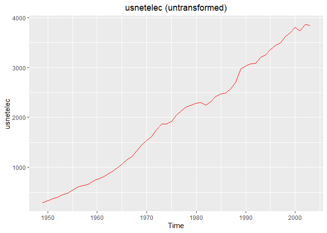

```r
### plot raw data series
autoplot(usnetelec) +
  ggtitle(paste("usnetelec (untransformed)")) +
  theme(plot.title = element_text(hjust = 0.5))+
  geom_line(color="red")
```

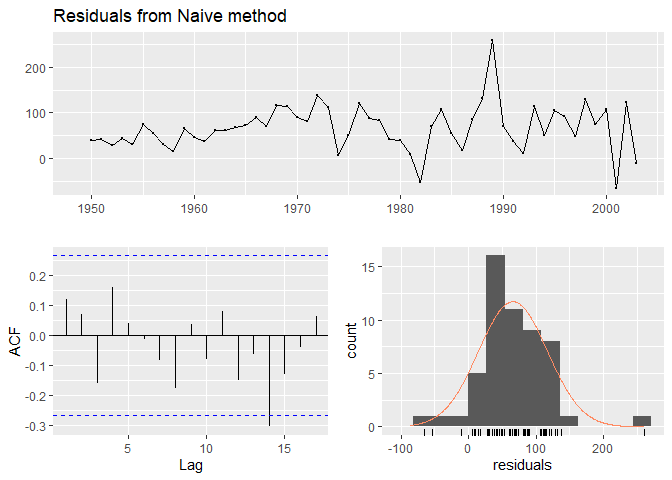

```
##
##  Ljung-Box test
##
## data:  Residuals from Naive method
## Q* = 7.4406, df = 10, p-value = 0.6833
##
## Model df: 0.   Total lags used: 10
```

```r
usnetelec.ljung <- checkresiduals(naive(usnetelec))
```

```r
#usnetelec.ljung

if (usnetelec.ljung$p.value > 0.05) {
  print("Because the p-value on the Ljung-Box test is large,
        the Box-Cox transform is not necessary, but here goes:")
}  else  {
    print("Because the p-value on the Ljung-Box test is small,
          we'll try Box-Cox transform to see if we can achieve constant variance")}
```

```
## [1] "Because the p-value on the Ljung-Box test is large, \n        the Box-Cox transform is not necessary, but here goes:"
```

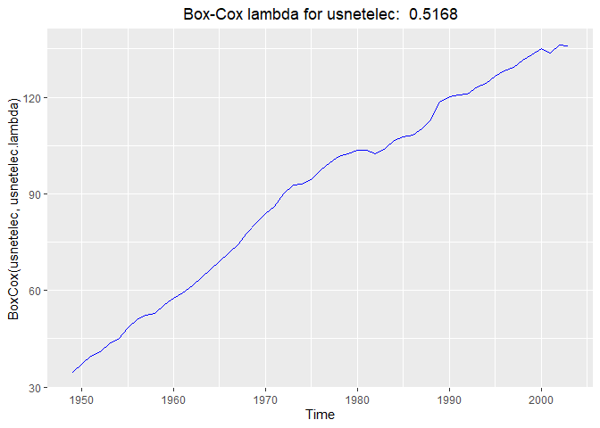

```r
### Box-Cox transform
usnetelec.lambda <- BoxCox.lambda(usnetelec)
### Plot transformed series
#print(paste("Box-Cox lambda for usnetelec: ", round(usnetelec.lambda,3)))
autoplot(BoxCox(usnetelec, usnetelec.lambda)) +
  ggtitle(paste("Box-Cox lambda for usnetelec: ", round(usnetelec.lambda,4))) +
  theme(plot.title = element_text(hjust = 0.5))+
  geom_line(color="blue")
```

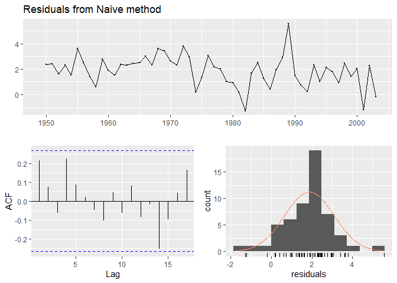

```
##
##  Ljung-Box test
##
## data:  Residuals from Naive method
## Q* = 7.9451, df = 10, p-value = 0.6342
##
## Model df: 0.   Total lags used: 10
```

```r
usnetelec.xform.ljung <- checkresiduals(naive(BoxCox(usnetelec, usnetelec.lambda)))
```

```r
#usnetelec.xform.ljung
```

### `usgdp` : Quarterly US GDP. 1947:1 - 2006.1

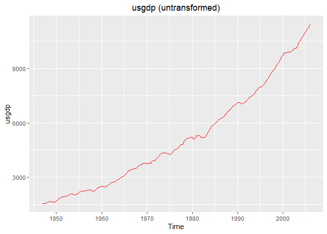

```r
### plot raw data series
autoplot(usgdp) +
  ggtitle(paste("usgdp (untransformed)")) +
  theme(plot.title = element_text(hjust = 0.5))+
  geom_line(color="red")
```

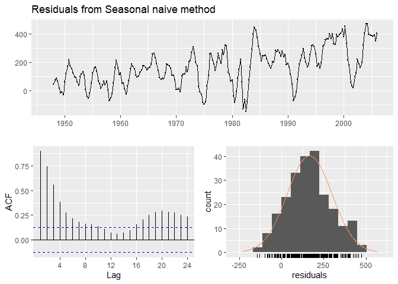

```
##
##  Ljung-Box test
##
## data:  Residuals from Seasonal naive method
## Q* = 473.66, df = 8, p-value < 0.00000000000000022
##
## Model df: 0.   Total lags used: 8
```

```r
usgdp.ljung <- checkresiduals(snaive(usgdp))
```

```r
#usgdp.ljung

if (usgdp.ljung$p.value > 0.05) {
  print("Because the p-value on the Ljung-Box test is large,
        the Box-Cox transform is not necessary, but here goes:")
}  else  {
    print("Because the p-value on the Ljung-Box test is small,
          we'll try Box-Cox transform to see if we can achieve constant variance")}
```

```
## [1] "Because the p-value on the Ljung-Box test is small, \n          we'll try Box-Cox transform to see if we can achieve constant variance"
```

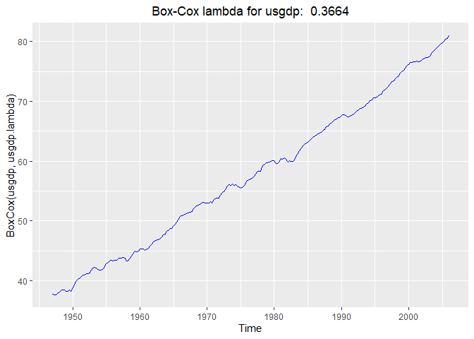

```r
### Box-Cox transform
usgdp.lambda <- BoxCox.lambda(usgdp)
### Plot transformed series
#print(paste("Box-Cox lambda for usgdp: ", round(usgdp.lambda,3)))
autoplot(BoxCox(usgdp, usgdp.lambda)) +
  ggtitle(paste("Box-Cox lambda for usgdp: ", round(usgdp.lambda,4))) +
  theme(plot.title = element_text(hjust = 0.5))+
  geom_line(color="blue")
```

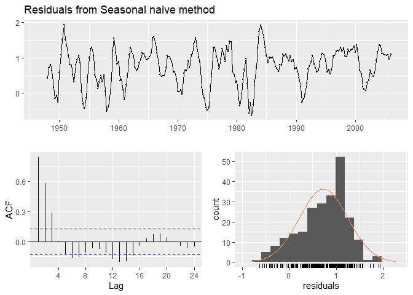

```
##
##  Ljung-Box test
##
## data:  Residuals from Seasonal naive method
## Q* = 285.76, df = 8, p-value < 0.00000000000000022
##
## Model df: 0.   Total lags used: 8
```

```r
usgdp.xform.ljung <- checkresiduals(snaive(BoxCox(usgdp, usgdp.lambda)))
```

```r
#usgdp.xform.ljung
```

### `mcopper` : Monthly copper prices. Copper, grade A, electrolytic wire bars/cathodes,LME,cash (pounds/ton)

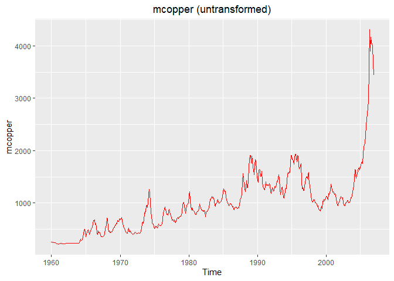

```r
### plot raw data series
autoplot(mcopper) +
  ggtitle(paste("mcopper (untransformed)")) +
  theme(plot.title = element_text(hjust = 0.5))+
  geom_line(color="red")
```

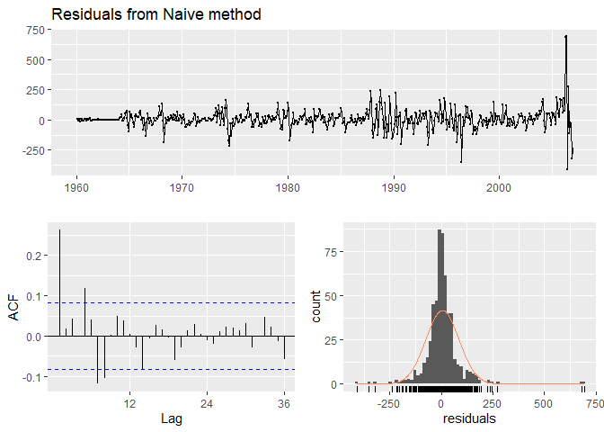

```
##
##  Ljung-Box test
##
## data:  Residuals from Naive method
## Q* = 74.063, df = 24, p-value = 0.0000005216
##
## Model df: 0.   Total lags used: 24
```

```r
mcopper.ljung <- checkresiduals(naive(mcopper))
```

```r
#mcopper.ljung

if (mcopper.ljung$p.value > 0.05) {
  print("Because the p-value on the Ljung-Box test is large,
        the Box-Cox transform is not necessary, but here goes:")
}  else  {
    print("Because the p-value on the Ljung-Box test is small,
          we'll try Box-Cox transform to see if we can achieve constant variance")}
```

```
## [1] "Because the p-value on the Ljung-Box test is small, \n          we'll try Box-Cox transform to see if we can achieve constant variance"
```

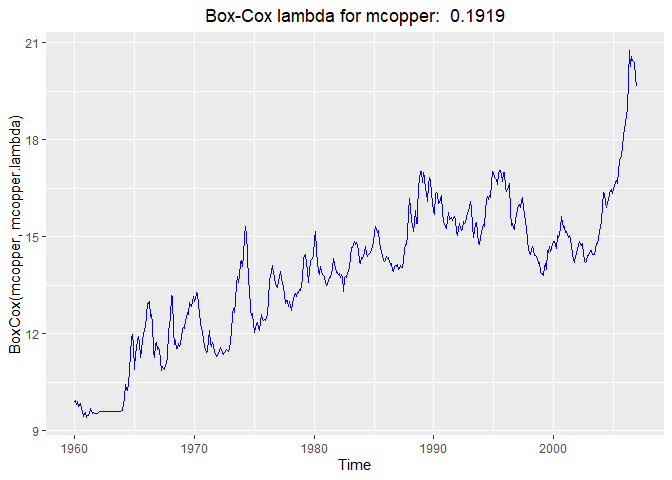

```r
### Box-Cox transform
mcopper.lambda <- BoxCox.lambda(mcopper)
### Plot transformed series
#print(paste("Box-Cox lambda for mcopper: ", round(mcopper.lambda,3)))
autoplot(BoxCox(mcopper, mcopper.lambda)) +
  ggtitle(paste("Box-Cox lambda for mcopper: ", round(mcopper.lambda,4))) +
  theme(plot.title = element_text(hjust = 0.5))+
  geom_line(color="blue")
```

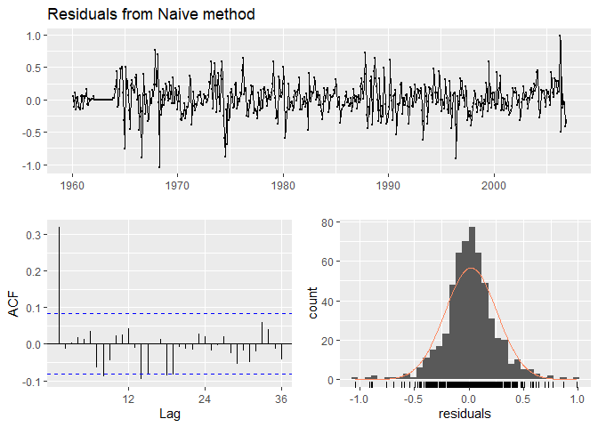

```
##
##  Ljung-Box test
##
## data:  Residuals from Naive method
## Q* = 87.597, df = 24, p-value = 0.000000003588
##
## Model df: 0.   Total lags used: 24
```

```r
mcopper.xform.ljung <- checkresiduals(naive(BoxCox(mcopper, mcopper.lambda)))
```

```r
#mcopper.xform.ljung
```

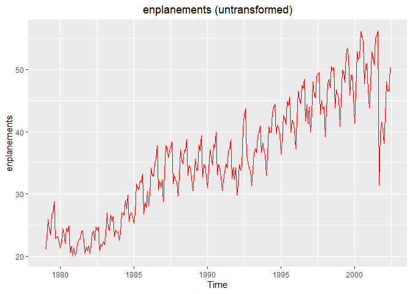

```r
### plot raw data series
autoplot(enplanements) +
  ggtitle(paste("enplanements (untransformed)")) +
  theme(plot.title = element_text(hjust = 0.5))+
  geom_line(color="red")
```

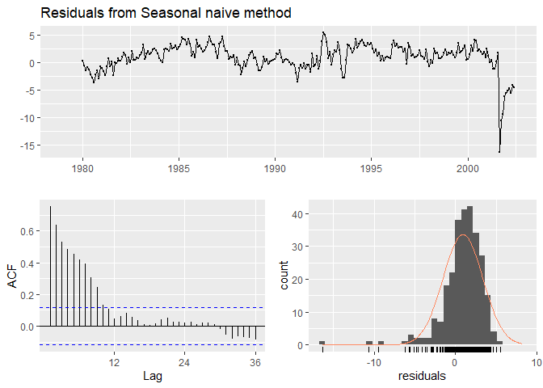

```
##
##  Ljung-Box test
##
## data:  Residuals from Seasonal naive method
## Q* = 614.48, df = 24, p-value < 0.00000000000000022
##
## Model df: 0.   Total lags used: 24
```

```r
enplanements.ljung <- checkresiduals(snaive(enplanements))
```

```r
#enplanements.ljung

if (enplanements.ljung$p.value > 0.05) {
  print("Because the p-value on the Ljung-Box test is large,
        the Box-Cox transform is not necessary, but here goes:")
}  else  {
    print("Because the p-value on the Ljung-Box test is small,
          we'll try Box-Cox transform to see if we can achieve constant variance")}
```

```
## [1] "Because the p-value on the Ljung-Box test is small, \n          we'll try Box-Cox transform to see if we can achieve constant variance"
```

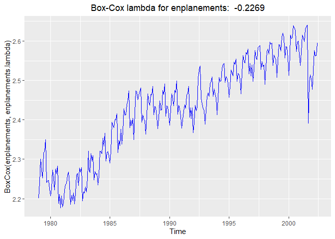

```r
### Box-Cox transform
enplanements.lambda <- BoxCox.lambda(enplanements)
### Plot transformed series
#print(paste("Box-Cox lambda for enplanements: ", round(enplanements.lambda,3)))
autoplot(BoxCox(enplanements, enplanements.lambda)) +
  ggtitle(paste("Box-Cox lambda for enplanements: ", round(enplanements.lambda,4))) +
  theme(plot.title = element_text(hjust = 0.5))+
  geom_line(color="blue")
```

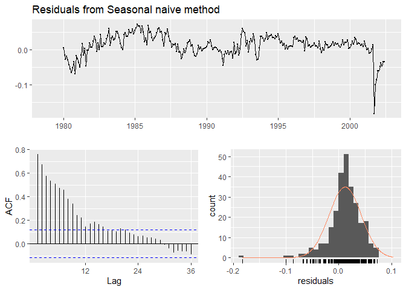

```
##
##  Ljung-Box test
##
## data:  Residuals from Seasonal naive method
## Q* = 809.1, df = 24, p-value < 0.00000000000000022
##
## Model df: 0.   Total lags used: 24
```

```r
enplanements.xform.ljung <- checkresiduals(snaive(BoxCox(enplanements, enplanements.lambda)))
```

```r
#enplanements.xform.ljung
```

## 3.2 Why is a Box-Cox transformation unhelpful for the cangas data?

### `cangas` : Monthly Canadian gas production, billions of cubic metres, January 1960 - February 2005

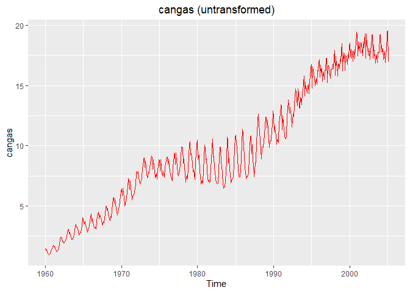

```r
### plot raw data series
autoplot(cangas) +
  ggtitle(paste("cangas (untransformed)")) +
  theme(plot.title = element_text(hjust = 0.5))+
  geom_line(color="red")
```

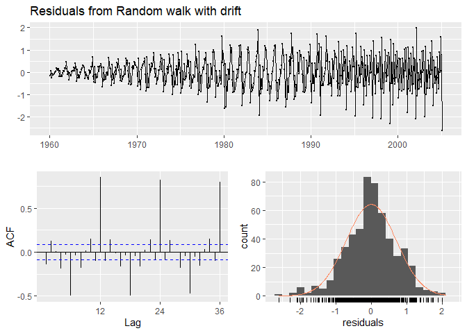

```
##
##  Ljung-Box test
##
## data:  Residuals from Random walk with drift
## Q* = 1207.3, df = 23, p-value < 0.00000000000000022
##
## Model df: 1.   Total lags used: 24
```

```r
cangas.ljung <- checkresiduals(rwf(cangas,h=2*frequency(cangas),drift=T))
```

```r
#cangas.ljung

if (cangas.ljung$p.value > 0.05) {
  print("Because the p-value on the Ljung-Box test is large,
        the Box-Cox transform is not necessary, but here goes:")
}  else  {
    print("Because the p-value on the Ljung-Box test is small,
          we'll try Box-Cox transform to see if we can achieve constant variance")}
```

```
## [1] "Because the p-value on the Ljung-Box test is small, \n          we'll try Box-Cox transform to see if we can achieve constant variance"
```

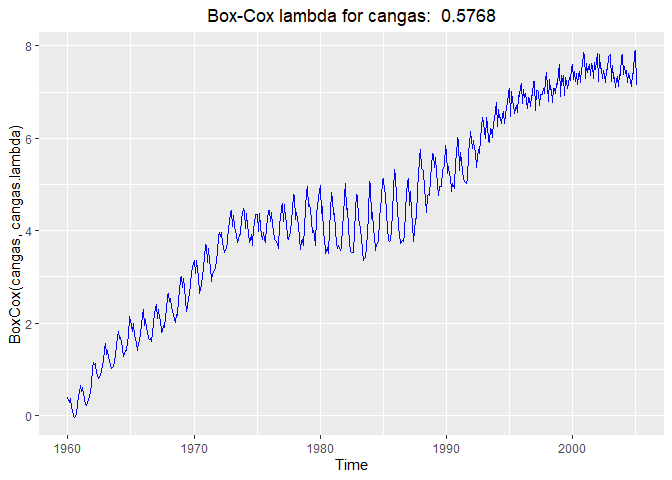

```r
### Box-Cox transform
cangas.lambda <- BoxCox.lambda(cangas)
### Plot transformed series
#print(paste("Box-Cox lambda for cangas: ", round(cangas.lambda,3)))
autoplot(BoxCox(cangas, cangas.lambda)) +
  ggtitle(paste("Box-Cox lambda for cangas: ", round(cangas.lambda,4))) +
  theme(plot.title = element_text(hjust = 0.5))+
  geom_line(color="blue")
```

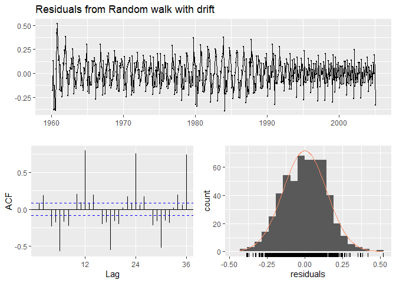

```
##
##  Ljung-Box test
##
## data:  Residuals from Random walk with drift
## Q* = 1307.8, df = 23, p-value < 0.00000000000000022
##
## Model df: 1.   Total lags used: 24
```

```r
cangas.xform.ljung <- checkresiduals(rwf(BoxCox(cangas, cangas.lambda),h=2*frequency(cangas),drift=T,lambda=cangas.lambda))
```

```r
#cangas.xform.ljung
```

The raw data series for `cangas` exhibits much higher variance during the middle years (late 1970s through early 1990s) and lower variance in the early and later years. The Box-Cox transformation is unable to stabilize this pattern.

## 3.3. What Box-Cox transformation would you select for your retail data (from Exercise 3 in Section 2.10)?

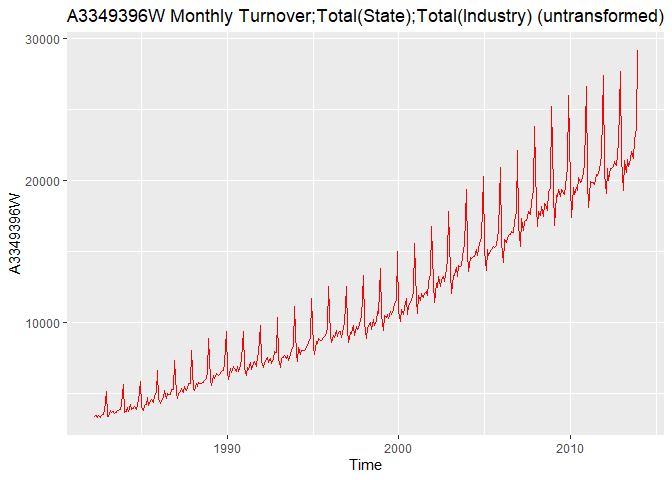

```r
#### You can read the data into R with the following script:
#### readxl does not read straight from URL without local download
####retaildata <- readxl::read_excel("https://otexts.com/fpp2/extrafiles/retail.xlsx", skip=1)
retaildata <- readxl::read_excel("retail.xlsx", skip=1)
#### The second argument (`skip=1`) is required because the Excel sheet has two header rows.

##myts <- ts(retaildata[,"A3349873A"],
##  frequency=12, start=c(1982,4))
#### Select one of the time series as follows
#### (but replace the column name with your own chosen column):

mycode <- "A3349396W"
mytitle <-  "Monthly Turnover;Total(State);Total(Industry)"
mymain <- paste(mycode,mytitle)
myts <- ts(retaildata[,"A3349396W"],
  frequency=12, start=c(1982,4))


### plot raw data series
autoplot(myts) +
  ggtitle(paste(mymain, "(untransformed)")) +
  ylab(mycode)+
  theme(plot.title = element_text(hjust = 0.5))+
  geom_line(color="red")
```

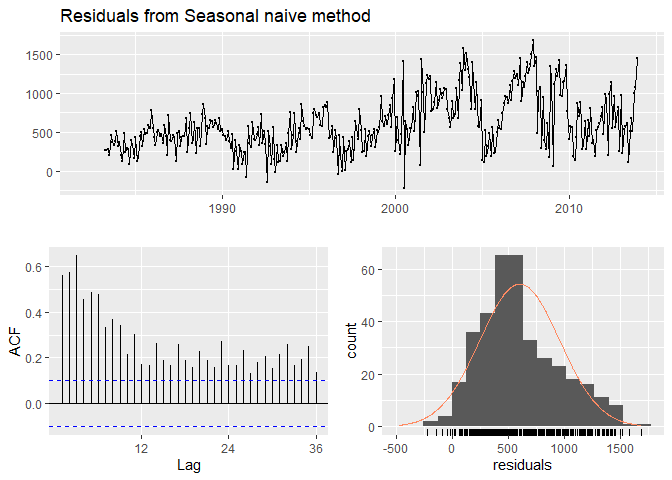

```
##
##  Ljung-Box test
##
## data:  Residuals from Seasonal naive method
## Q* = 1045.2, df = 24, p-value < 0.00000000000000022
##
## Model df: 0.   Total lags used: 24
```

```r
myts.ljung <- checkresiduals(snaive(myts))
```

```r
#myts.ljung

if (myts.ljung$p.value > 0.05) {
  print("Because the p-value on the Ljung-Box test is large,
        the Box-Cox transform is not necessary, but here goes:")
}  else  {
    print("Because the p-value on the Ljung-Box test is small,
          we'll try Box-Cox transform to see if we can achieve constant variance")}
```

```
## [1] "Because the p-value on the Ljung-Box test is small, \n          we'll try Box-Cox transform to see if we can achieve constant variance"
```

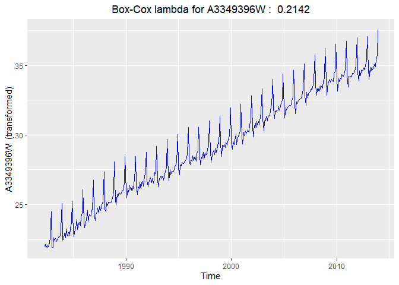

```r
### Box-Cox transform
myts.lambda <- BoxCox.lambda(myts)
### Plot transformed series
#print(paste("Box-Cox lambda for myts: ", round(myts.lambda,3)))
autoplot(BoxCox(myts, myts.lambda)) +
  ggtitle(paste("Box-Cox lambda for", mycode, ": ", round(myts.lambda,4))) +
  ylab(paste(mycode," (transformed)"))+
  theme(plot.title = element_text(hjust = 0.5))+
  geom_line(color="blue")
```

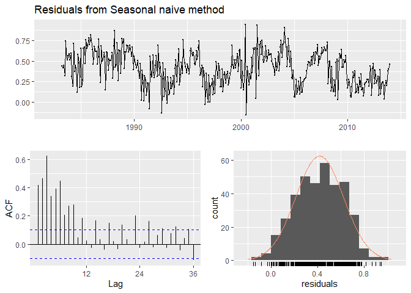

```
##
##  Ljung-Box test
##
## data:  Residuals from Seasonal naive method
## Q* = 602.81, df = 24, p-value < 0.00000000000000022
##
## Model df: 0.   Total lags used: 24
```

```r
myts.xform.ljung <- checkresiduals(snaive(BoxCox(myts, myts.lambda)))
```

```r
#myts.xform.ljung
```

The Box-Cox transformation selected for this data series is $\lambda = 0.2142$ .

## 3.8 For your retail time series (from Exercise 3 in Section 2.10):

### a) Split the data into two parts using

```r
myts.train <- window(myts, end=c(2010,12))
myts.test <- window(myts, start=2011)
```

### b) Check that your data have been split appropriately by producing the following plot.

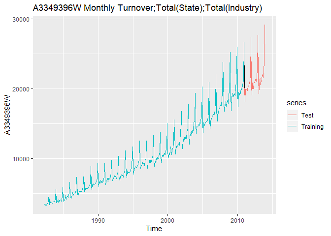

```r
autoplot(myts) +
  autolayer(myts.train, series="Training") +
  autolayer(myts.test, series="Test")  +
  ggtitle(mymain)+
  ylab(mycode)
```

### c) Calculate forecasts using `snaive` applied to `myts.train`.

##### Note: To get 36 months of forecast (3 years) we have to specify h=36

##### If we don’t specify a value for h then we will get the default, which is only 2 years (24 months)

```r
fc <- snaive(myts.train,h=length(myts.test))
fc
```

```
##          Point Forecast    Lo 80    Hi 80    Lo 95    Hi 95
## Jan 2011        19792.0 18895.89 20688.11 18421.52 21162.48
## Feb 2011        17431.5 16535.39 18327.61 16061.02 18801.98
## Mar 2011        19490.3 18594.19 20386.41 18119.82 20860.78
## Apr 2011        19032.0 18135.89 19928.11 17661.52 20402.48
## May 2011        19533.6 18637.49 20429.71 18163.12 20904.08
## Jun 2011        19339.1 18442.99 20235.21 17968.62 20709.58
## Jul 2011        20231.6 19335.49 21127.71 18861.12 21602.08
## Aug 2011        19860.8 18964.69 20756.91 18490.32 21231.28
## Sep 2011        19916.3 19020.19 20812.41 18545.82 21286.78
## Oct 2011        20575.4 19679.29 21471.51 19204.92 21945.88
## Nov 2011        21163.7 20267.59 22059.81 19793.22 22534.18
## Dec 2011        26599.2 25703.09 27495.31 25228.72 27969.68
## Jan 2012        19792.0 18524.71 21059.29 17853.85 21730.15
## Feb 2012        17431.5 16164.21 18698.79 15493.35 19369.65
## Mar 2012        19490.3 18223.01 20757.59 17552.15 21428.45
## Apr 2012        19032.0 17764.71 20299.29 17093.85 20970.15
## May 2012        19533.6 18266.31 20800.89 17595.45 21471.75
## Jun 2012        19339.1 18071.81 20606.39 17400.95 21277.25
## Jul 2012        20231.6 18964.31 21498.89 18293.45 22169.75
## Aug 2012        19860.8 18593.51 21128.09 17922.65 21798.95
## Sep 2012        19916.3 18649.01 21183.59 17978.15 21854.45
## Oct 2012        20575.4 19308.11 21842.69 18637.25 22513.55
## Nov 2012        21163.7 19896.41 22430.99 19225.55 23101.85
## Dec 2012        26599.2 25331.91 27866.49 24661.05 28537.35
## Jan 2013        19792.0 18239.90 21344.10 17418.26 22165.74
## Feb 2013        17431.5 15879.40 18983.60 15057.76 19805.24
## Mar 2013        19490.3 17938.20 21042.40 17116.56 21864.04
## Apr 2013        19032.0 17479.90 20584.10 16658.26 21405.74
## May 2013        19533.6 17981.50 21085.70 17159.86 21907.34
## Jun 2013        19339.1 17787.00 20891.20 16965.36 21712.84
## Jul 2013        20231.6 18679.50 21783.70 17857.86 22605.34
## Aug 2013        19860.8 18308.70 21412.90 17487.06 22234.54
## Sep 2013        19916.3 18364.20 21468.40 17542.56 22290.04
## Oct 2013        20575.4 19023.30 22127.50 18201.66 22949.14
## Nov 2013        21163.7 19611.60 22715.80 18789.96 23537.44
## Dec 2013        26599.2 25047.10 28151.30 24225.46 28972.94
```

### d) Compare the accuracy of your forecasts against the actual values stored in myts.test.

```r
accuracy(fc,myts.test)
```

```
##                     ME     RMSE      MAE      MPE     MAPE     MASE      ACF1 Theil's U
## Training set  598.4838  699.236  601.506 5.961516 5.997664 1.000000 0.5972618        NA
## Test set     1230.1556 1389.337 1230.156 5.668187 5.668187 2.045126 0.7093345 0.6485265
```

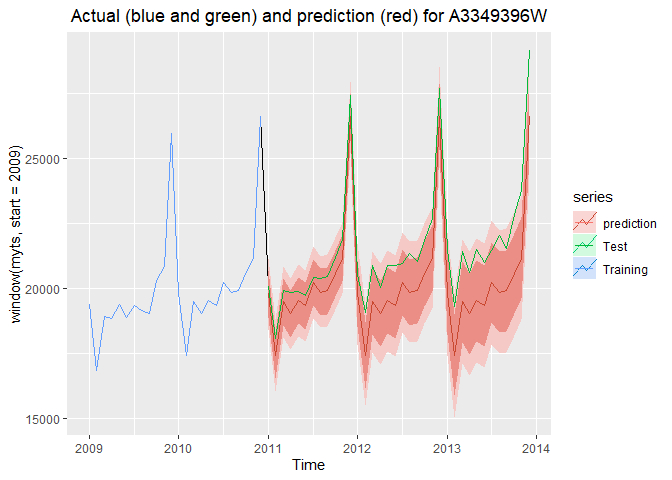

```r
autoplot(window(myts,start=2009)) +
  ggtitle(paste("Actual (blue and green) and prediction (red) for", mycode))+
  theme(plot.title = element_text(hjust = 0.5))+
  autolayer(window(myts.train,start=2009), series="Training") +
  autolayer(fc, series="prediction")+
  autolayer(myts.test, series="Test", )
```

### e) Check the residuals.

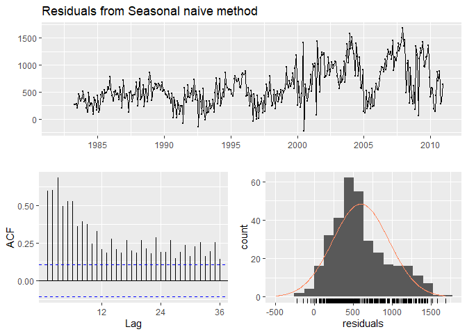

```
##
##  Ljung-Box test
##
## data:  Residuals from Seasonal naive method
## Q* = 1101, df = 24, p-value < 0.00000000000000022
##
## Model df: 0.   Total lags used: 24
```

```r
checkresiduals(fc)
```